[figure not shown]

LI-2

General Description

LIGHTING SYSTEM

1. General Description

A: SPECIFICATION

No. Description Capacity and wattage Type

(1) Headlight

Low beam (halogen type) 12 V — 55 W H11

Low beam (LED type) 12 V — 21.6 W *

High beam 12 V — 60 W HB3

Parking light (halogen type) 12 V — 5 W W5W

Parking light (LED type) 12 V — 1.5 W (LED) *

Side marker light 12 V — 5 W W5W

(2) Front fog light 12 V — 19 W H16

(3) Front turn signal light 12 V — 21 W WY21W

(4) Glove box light 12 V — 1.4 W (LED) *

(5) Pocket light 12 V — 1.4 W (LED) *

(6) Spot map light 12 V — 8 W —

(7) Room light 12 V — 8 W —

(8) Vanity mirror light 12 V — 2 W —

(9) Side turn signal light 12 V — 1.1 W (LED) *

(10) High-mounted stop light 12 V — 0.7 W (LED) *

(11) Trunk room light 12 V — 5 W W5W

(12) Rear combination light

Tail & stop light 12 V — 0.3/3.5 W (LED) *

Back-up light 12 V — 16 W W16W

Turn signal light 12 V — 21 W WY21W

Side marker light 12 V — 5 W W5W

(13) License plate light 12 V — 5 W W5W

*: Non-disassembly type

LI-01725

(2) (3)(1) (13)

(6) (7)(4) (5)

(8) (9) (10)

(12)

(11)

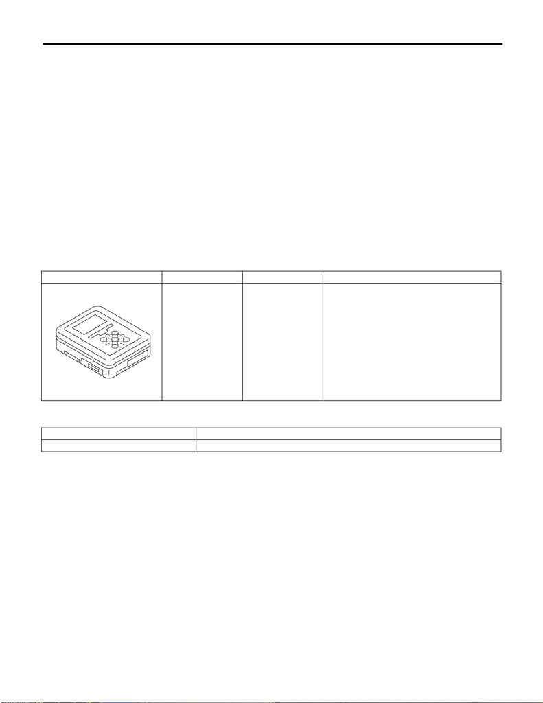

LI-3

General Description

LIGHTING SYSTEM

B: CAUTION

• Before disconnecting connectors of sensors or units, be sure to disconnect the ground cable from battery.

When replacing the audio and MFD parts provided with memory functions, record the memory contents be-

fore disconnecting the battery ground cable.

• Be careful of the following items. Failing to do so may cause the airbag system malfunction.

– Yellow connectors and harnesses with yellow tapes around them are the connectors and harnesses for

the airbag system. When using a tester on these circuits, follow the cautions of “AIRBAG SYSTEM”. <Ref.

to AB-9, CAUTION, General Description.>

– Be careful not to damage the airbag system wiring harness when servicing the electrical parts around

the steering column.

• When removing, installing or replacing the VDCCM&H/U, VDCCM&H/U bracket, steering wheel or steer-

ing angle sensor (steering roll connector), perform “VDC sensor midpoint setting mode” of the VDC. <Ref. to

VDC-16, VDC SENSOR MIDPOINT SETTING MODE, ADJUSTMENT, VDC Control Module and Hydraulic

Control Unit (VDCCM&H/U).>

• Use a dry clean cloth so that no grease or water adheres to the glass portion of the bulb.

• Always replace with a bulb that is the same model and wattage as those of the old one.

C: PREPARATION TOOL

1. SPECIAL TOOL

2. GENERAL TOOL

ILLUSTRATION TOOL NUMBER DESCRIPTION REMARKS

1B022XU0 SUBARU SELECT

MONITOR III KIT

Used for setting of each function and trouble-

shooting for electrical system.

NOTE:

For detailed operation procedures of SUBARU

SELECT MONITOR III KIT, refer to “PC applica-

tion help for Subaru Select Monitor”.

TOOL NAME REMARKS

Circuit tester Used for measuring resistance and voltage.

ST1B022XU0